# lab-ch6-2

Austin Melendez

2026-03-05

Section 6.6: Exercises 9, 11

```r
library(ISLR2)
library(glmnet)
library(pls)
library(leaps)
```

## Exercise 9

Predict the number of applications received using the other variables in the `College` data set.

### A

Split the data into Train/Test sets

```r
data(College)

set.seed(1)
train <- sample(1:nrow(College), nrow(College)/2)

test <- -train
```

### B

Fit a linear model using least squares on the training set, and report the test error.

```r
lm.fit <- lm(Apps ~ ., data=College, subset=train)

lm.pred <- predict(lm.fit, College[test,])

lm.test.mse <- mean((College$Apps[test] - lm.pred)^2)

lm.test.mse
```

```
## [1] 1135758
```

### C

Fit a ridge regression model on the training set, with $\lambda$ chosen by cross-validation. Report the test error.

```r
x <- model.matrix(Apps~., College)[,-1]
y <- College$Apps

set.seed(1)

cv.ridge <- cv.glmnet(x[train,], y[train], alpha=0)

ridge.pred <- predict(cv.ridge,
                      s=cv.ridge$lambda.min,
                      newx=x[test,])

ridge.mse <- mean((ridge.pred - y[test])^2)

ridge.mse
```

```
## [1] 976261.5
```

### D

Fit a lasso model on the training set, with $\lambda$ chosen by cross-validation. Report the test error and number of non-zero coefficient estimates.

```r
set.seed(1)

cv.lasso <- cv.glmnet(x[train,], y[train], alpha=1)

lasso.pred <- predict(cv.lasso,
                      s=cv.lasso$lambda.min,
                      newx=x[test,])

lasso.mse <- mean((lasso.pred - y[test])^2)

lasso.mse
```

```
## [1] 1115901
```

Number of non-zero coefficients:

```r
lasso.coef <- predict(cv.lasso,
                      type="coefficients",
                      s=cv.lasso$lambda.min)

sum(lasso.coef != 0)
```

```
## [1] 18
```

### E

Fit a PCR model on the training set, with $M$ chosen by cross-validation. Report the test error obtained, along with the value of $M$ selected by cross-validation.

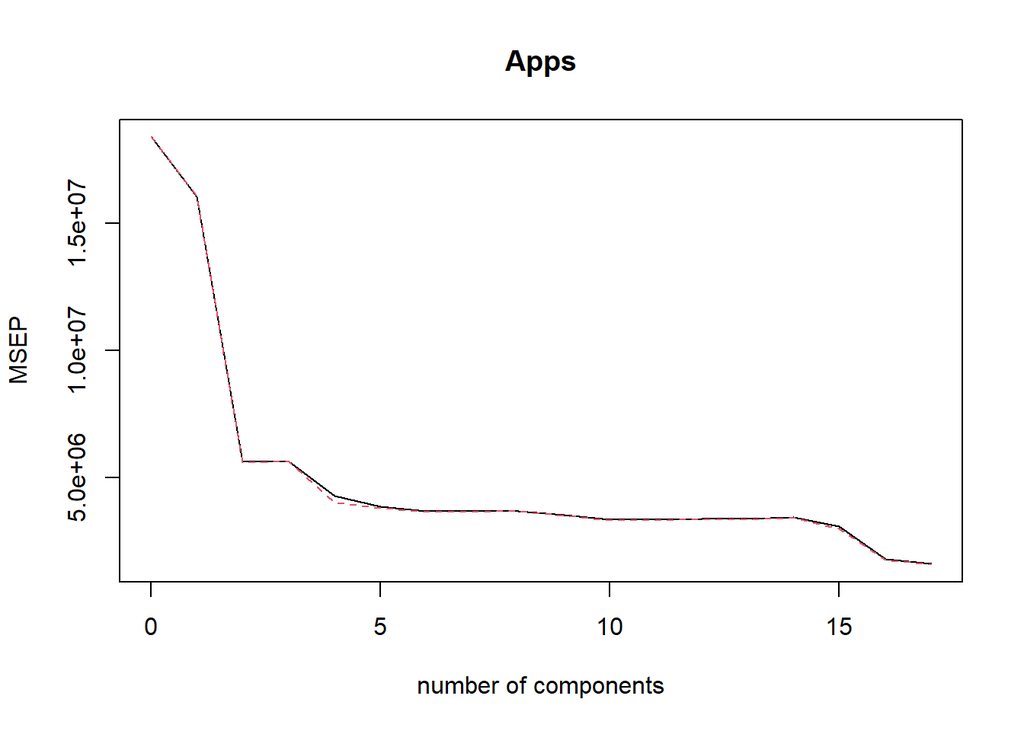

```r
set.seed(1)

pcr.fit <- pcr(Apps~., data=College,
               subset=train,
               scale=TRUE,
               validation="CV")

validationplot(pcr.fit, val.type="MSEP")
```

```r
pcr.pred <- predict(pcr.fit,
                    College[test,],
                    ncomp=10)

pcr.mse <- mean((pcr.pred - College$Apps[test])^2)

pcr.mse
```

```
## [1] 1723100
```

$M$ value:

```r
summary(pcr.fit)
```

```
## Data:    X dimension: 388 17
##  Y dimension: 388 1
## Fit method: svdpc
## Number of components considered: 17
##
## VALIDATION: RMSEP
## Cross-validated using 10 random segments.
##        (Intercept)  1 comps  2 comps  3 comps  4 comps  5 comps  6 comps
## CV            4288     4006     2373     2372     2069     1961     1919
## adjCV         4288     4007     2368     2369     1999     1948     1911
##        7 comps  8 comps  9 comps  10 comps  11 comps  12 comps  13 comps
## CV        1919     1921     1876      1832      1832      1836      1837
## adjCV     1912     1915     1868      1821      1823      1827      1827
##        14 comps  15 comps  16 comps  17 comps
## CV         1853      1759      1341      1270
## adjCV      1850      1733      1326      1257
##
## TRAINING: % variance explained
##       1 comps  2 comps  3 comps  4 comps  5 comps  6 comps  7 comps  8 comps
## X       32.20    57.78    65.31    70.99    76.37    81.27     84.8    87.85
## Apps    13.44    70.93    71.07    79.87    81.15    82.25     82.3    82.33
##       9 comps  10 comps  11 comps  12 comps  13 comps  14 comps  15 comps
## X       90.62     92.91     94.98     96.74     97.79     98.72     99.42
## Apps    83.38     84.76     84.80     84.84     85.11     85.14     90.55
##       16 comps  17 comps
## X        99.88    100.00
## Apps     93.42     93.89
## (389 observations deleted due to missingness)
```

### F

Fit a PLS model on the training set, with $M$ chosen by cross-validation. Report the test error obtained, along with the value of $M$ selected by cross-validation.

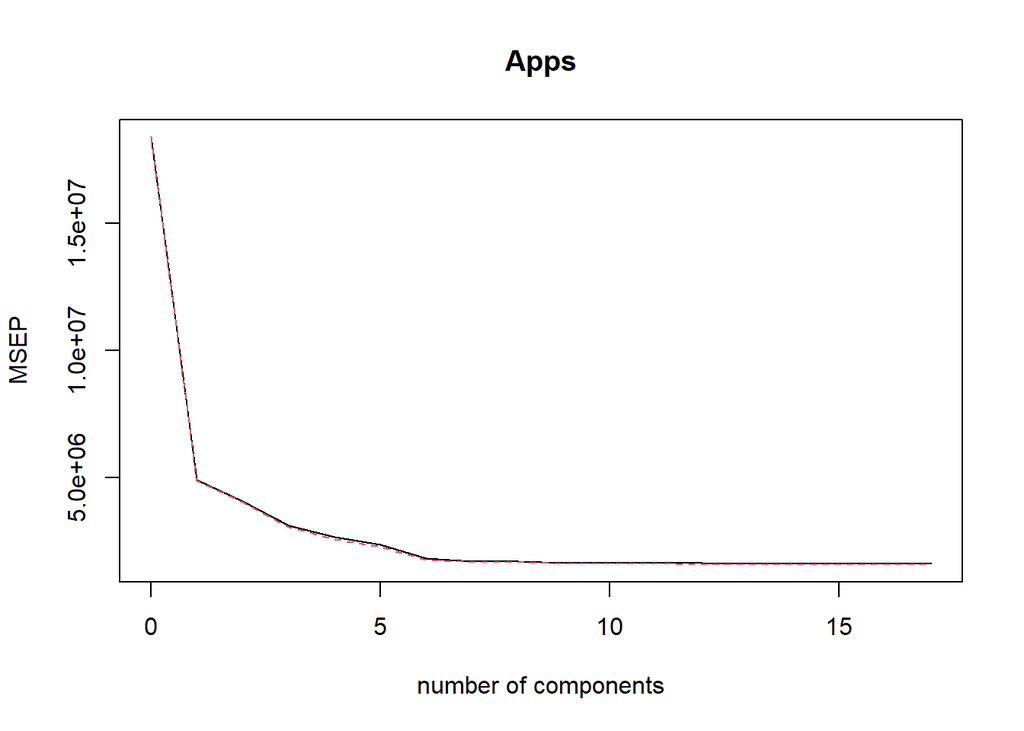

```r
set.seed(1)

pls.fit <- plsr(Apps~., data=College,
                subset=train,
                scale=TRUE,
                validation="CV")

validationplot(pls.fit, val.type="MSEP")
```

```r
pls.pred <- predict(pls.fit,
                    College[test,],
                    ncomp=10)

pls.mse <- mean((pls.pred - College$Apps[test])^2)

pls.mse
```

```
## [1] 1131661
```

$M$ value:

```r
summary(pls.fit)
```

```
## Data:    X dimension: 388 17
##  Y dimension: 388 1
## Fit method: kernelpls
## Number of components considered: 17
##
## VALIDATION: RMSEP
## Cross-validated using 10 random segments.
##        (Intercept)  1 comps  2 comps  3 comps  4 comps  5 comps  6 comps
## CV            4288     2217     2019     1761     1630     1533     1347
## adjCV         4288     2211     2012     1749     1605     1510     1331
##        7 comps  8 comps  9 comps  10 comps  11 comps  12 comps  13 comps
## CV        1309     1303     1286      1283      1283      1277      1271
## adjCV     1296     1289     1273      1270      1270      1264      1258
##        14 comps  15 comps  16 comps  17 comps
## CV         1270      1270      1270      1270
## adjCV      1258      1257      1257      1257
##
## TRAINING: % variance explained
##       1 comps  2 comps  3 comps  4 comps  5 comps  6 comps  7 comps  8 comps
## X       27.21    50.73    63.06    65.52    70.20    74.20    78.62    80.81
## Apps    75.39    81.24    86.97    91.14    92.62    93.43    93.56    93.68
##       9 comps  10 comps  11 comps  12 comps  13 comps  14 comps  15 comps
## X       83.29     87.17     89.15     91.37     92.58     94.42     96.98
## Apps    93.76     93.79     93.83     93.86     93.88     93.89     93.89
##       16 comps  17 comps
## X        98.78    100.00
## Apps     93.89     93.89
## (389 observations deleted due to missingness)
```

### G

How accurately can we predict the number of college applications received? Is there much difference among the test errors resulting from these five approaches?

```r
data.frame(
Method=c("Linear","Ridge","Lasso","PCR","PLS"),
Test_MSE=c(lm.test.mse,ridge.mse,lasso.mse,pcr.mse,pls.mse))
```

```
##   Method  Test_MSE
## 1 Linear 1135758.3
## 2  Ridge  976261.5
## 3  Lasso 1115900.6
## 4    PCR 1723099.7
## 5    PLS 1131660.8
```

## Exercise 11

```r
data(Boston)

set.seed(1)
train <- sample(1:nrow(Boston), nrow(Boston)/2)
test <- -train

regfit <- regsubsets(crim ~ ., data = Boston[train,], nvmax = 13)

reg.summary <- summary(regfit)

predict.regsubsets <- function(object, newdata, id){
  form <- as.formula(object$call[[2]])
  mat <- model.matrix(form, newdata)
  coefi <- coef(object, id = id)
  xvars <- names(coefi)
  mat[, xvars] %*% coefi
}

n.models <- length(reg.summary$rsq)

val.errors <- rep(NA, n.models)

for(i in 1:n.models){
  pred <- predict.regsubsets(regfit, Boston[test,], id = i)

  val.errors[i] <- mean((Boston$crim[test] - pred)^2)
}

val.errors[which.min(val.errors)]
```

```
## [1] 40.14557
```

#### Ridge Regression

```r
x <- model.matrix(crim~., Boston)[,-1]
y <- Boston$crim

cv.ridge <- cv.glmnet(x[train,],y[train],alpha=0)

ridge.pred <- predict(cv.ridge,
                      s=cv.ridge$lambda.min,
                      newx=x[test,])

mean((ridge.pred-y[test])^2)
```

```
## [1] 40.17065
```

#### Lasso

```r
cv.lasso <- cv.glmnet(x[train,],y[train],alpha=1)

lasso.pred <- predict(cv.lasso,
                      s=cv.lasso$lambda.min,
                      newx=x[test,])

mean((lasso.pred-y[test])^2)
```

```
## [1] 40.35922
```

#### Principal Component Regression (PCR)

```r
pcr.fit <- pcr(crim~., data=Boston,
               subset=train,
               scale=TRUE,
               validation="CV")

pcr.pred <- predict(pcr.fit,
                    Boston[test,],
                    ncomp=6)

mean((pcr.pred-Boston$crim[test])^2)
```

```
## [1] 42.86862
```

### B

Our best models are produces using ridge regression, lasso, and best subset selection. These methods all balance bias and variance well, producing a strong interpretable result. I would choose the best subset selection model since it has the lowest validation set error of $40.14557$.

### C

No, the model does not use all predictors. This is because some predictors contribute little helpful information to our model. Reducing these less helpful predictors can help reduce and prevent the risk of overfitting.